# Data visualisation II Univariate & Bivariate

O Rodriguez de Rivera Ortega, PhD

University of Exeter

# Univariate Graphs - Categorical

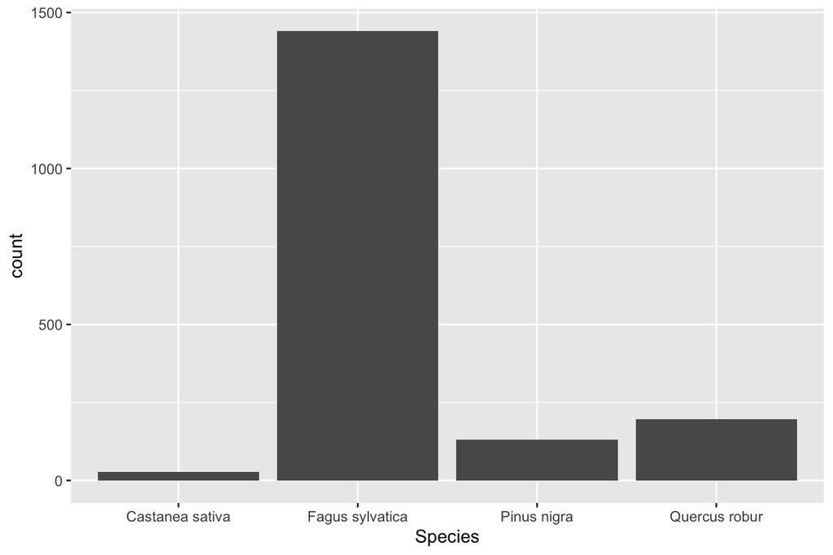

```r
library(ggplot2)
# plot the distribution of species
ggplot(FI_Murcia_sub, aes(x = Species)) +
  geom_bar()
```

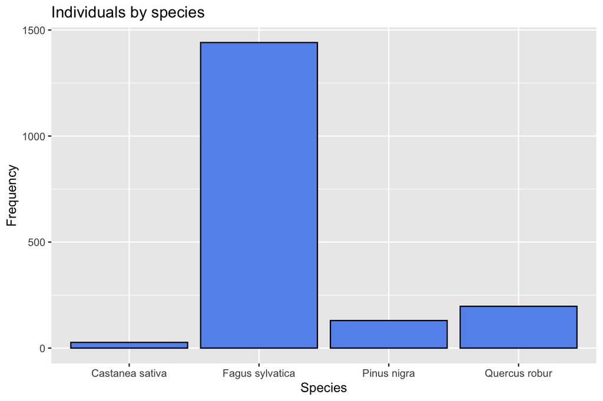

```r
# plot the distribution of race with modified colors and labels
ggplot(FI_Murcia_sub, aes(x = Species)) +
  geom_bar(fill = "cornflowerblue", color="black") +
  labs(x = "Species", y = "Frequency",
       title = "Individuals by species")
```

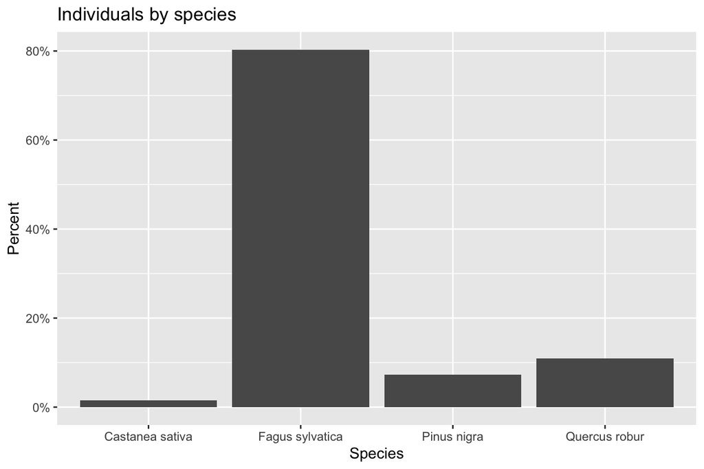

```r
# plot the distribution as percentages
ggplot(FI_Murcia_sub, aes(x = Species, y = ..count.. / sum(..count..))) +
  geom_bar() + labs(x = "Species", y = "Percent",
                    title = "Individuals by species") +
  scale_y_continuous(labels = scales::percent)
```

```r
# calculate number of participants in # each race category
library(dplyr)
```

```r
plotdata <- FI_Murcia_sub %>%
  count(Species)
plotdata
```

```
##           Species    n
## 1 Castanea sativa   27
## 2 Fagus sylvatica 1441
## 3     Pinus nigra  130
## 4   Quercus robur  197
```

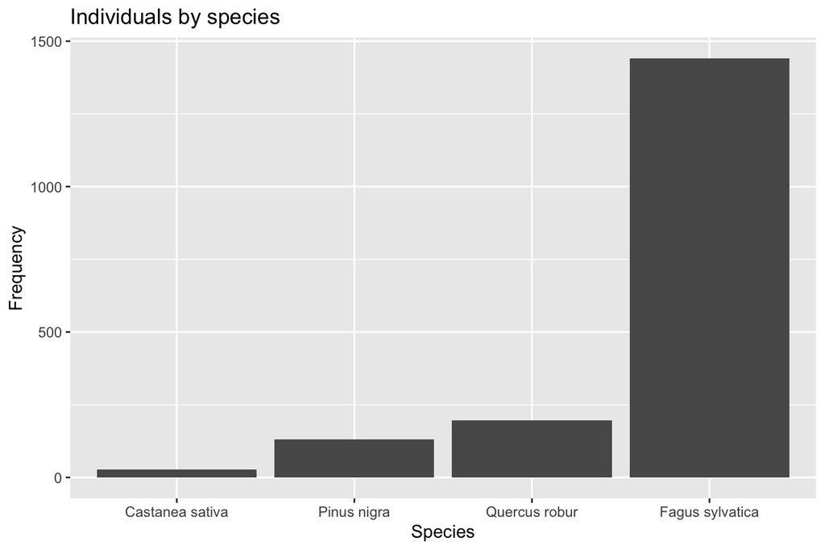

```r
# plot the bars in ascending order
ggplot(plotdata, aes(x = reorder(Species, n), y = n)) +
  geom_bar(stat = "identity") +
  labs(x = "Species", y = "Frequency",
       title = "Individuals by species")
```

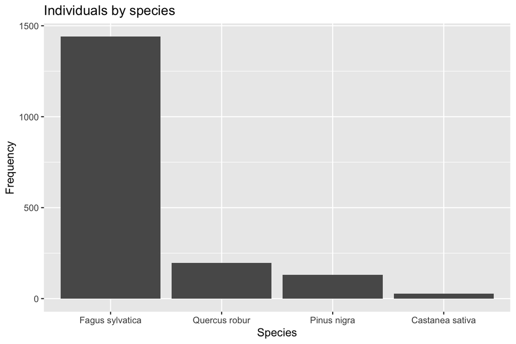

```r
# plot the bars in descending order
ggplot(plotdata, aes(x = reorder(Species, -n), y = n)) +
  geom_bar(stat = "identity") +
  labs(x = "Species", y = "Frequency",
       title = "Individuals by species")
```

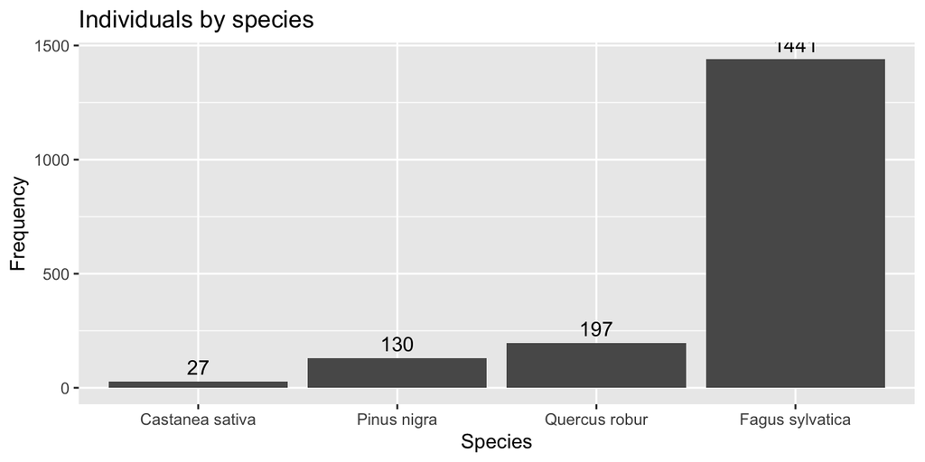

```r
# plot the bars with numeric labels
# geom_text adds the labels,
# vjust controls vertical justification
ggplot(plotdata, aes(x = reorder(Species, n), y = n)) +
  geom_bar(stat = "identity") +
  geom_text(aes(label = n), vjust=-0.5) +
  labs(x = "Species", y = "Frequency",
       title = "Individuals by species")
```

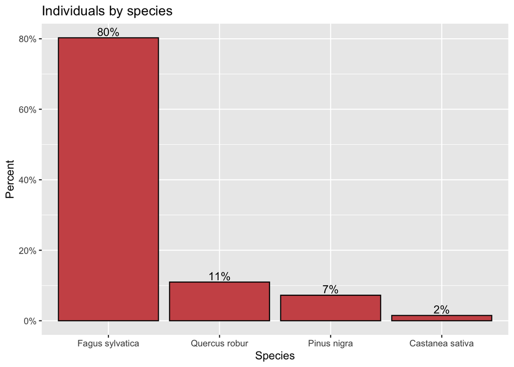

## Overlapping labels

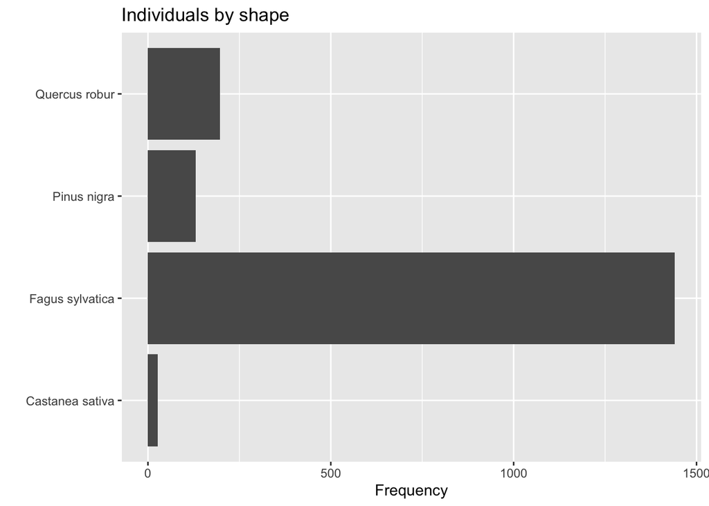

# Univariate Graphs - Quantitative

## Histogram

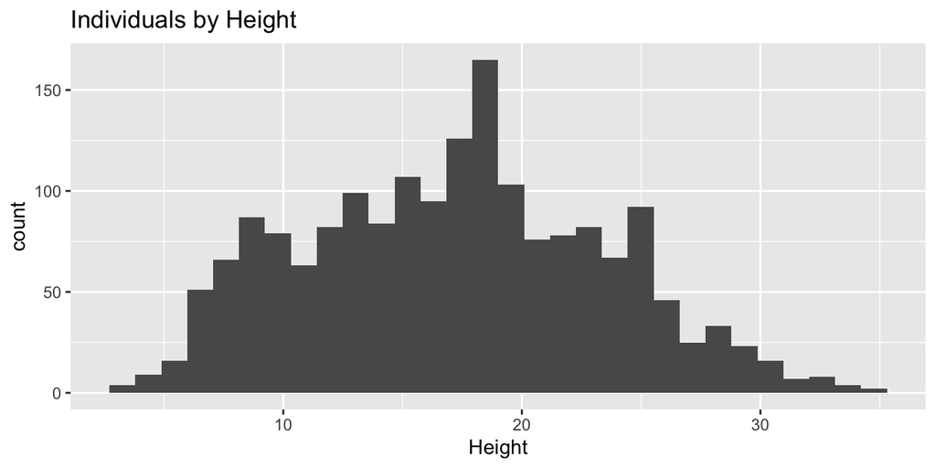

```r
# plot the age distribution using a histogram
ggplot(FI_Murcia_sub, aes(x = Height)) + geom_histogram() +
  labs(title = "Individuals by Height", x = "Height")
```

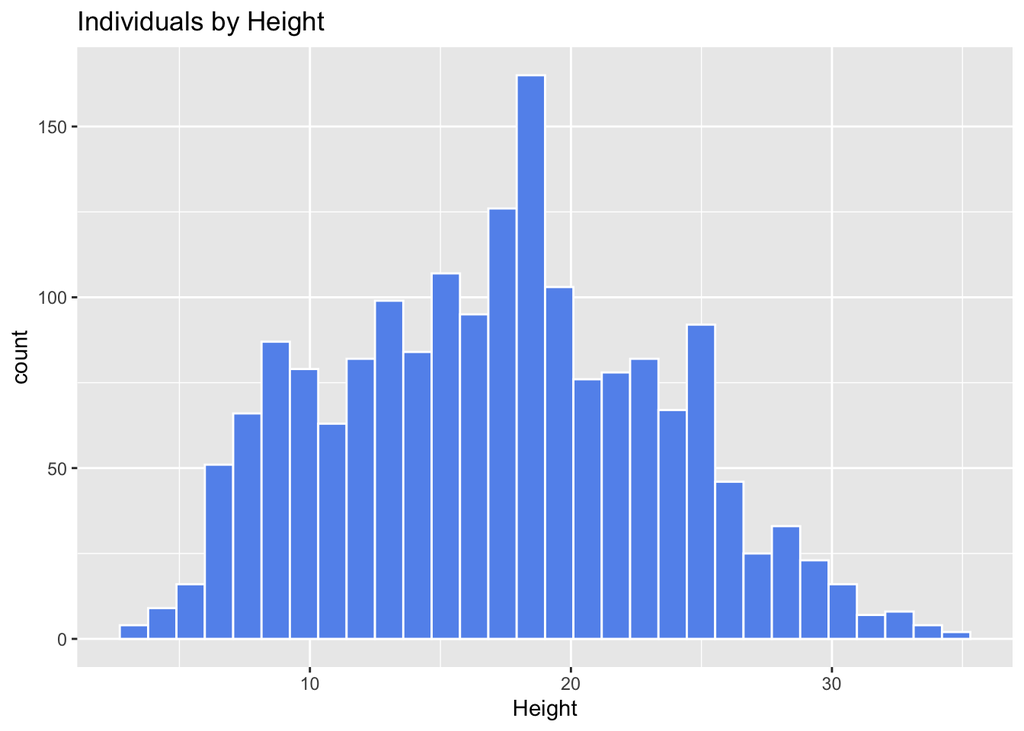

```r
# plot the histogram with blue bars and white borders
ggplot(FI_Murcia_sub, aes(x = Height)) +
  geom_histogram(fill = "cornflowerblue", color = "white") +
  labs(title = "Individuals by Height", x = "Height")
```

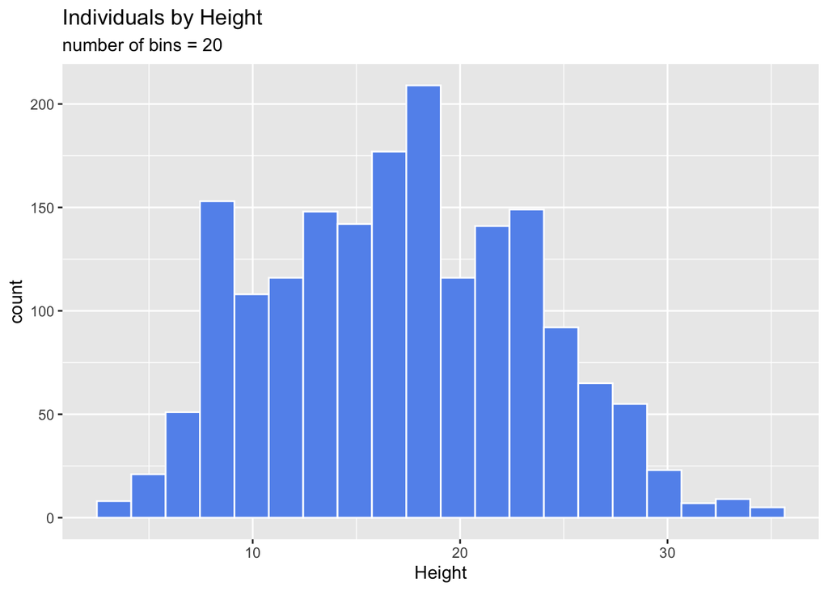

```r
# plot the histogram with 20 bins
ggplot(FI_Murcia_sub, aes(x = Height)) +
  geom_histogram(fill = "cornflowerblue", color = "white", bins = 20) +
  labs(title="Individuals by Height", subtitle = "number of bins = 20", x = "Height")
```

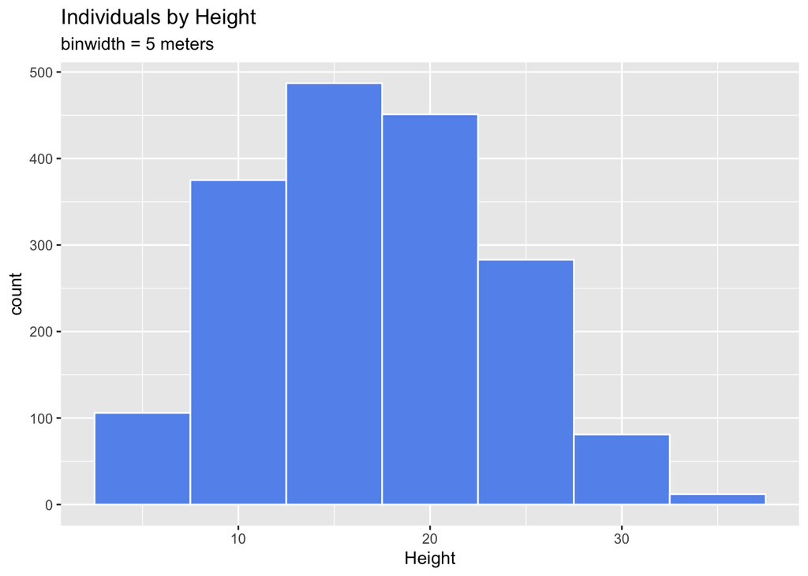

```r
# plot the histogram with a binwidth of 5
ggplot(FI_Murcia_sub, aes(x = Height)) +
  geom_histogram(fill = "cornflowerblue", color = "white", binwidth = 5) +
  labs(title="Individuals by Height", subtitle = "binwidth = 5 meters", x = "Height")
```

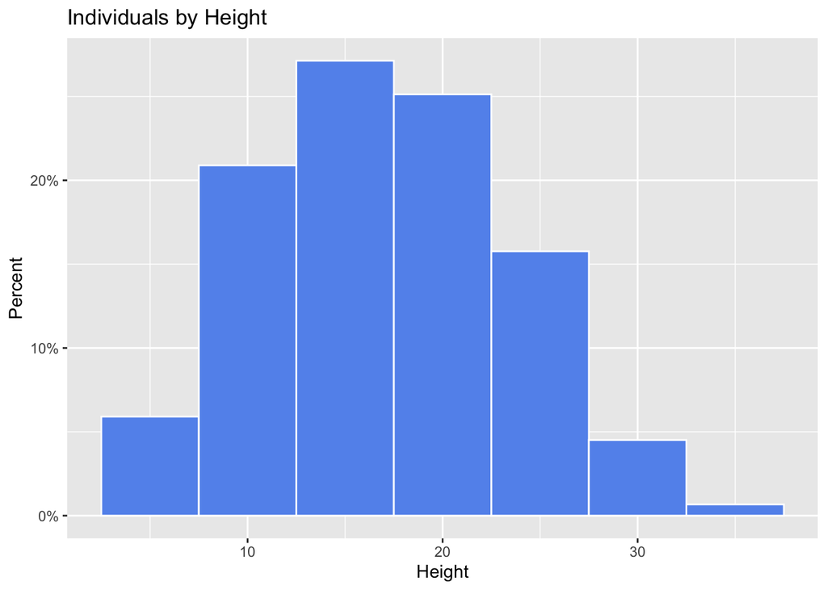

```r
# plot the histogram with percentages on the y-axis
library(scales)
ggplot(FI_Murcia_sub, aes(x = Height, y= ..count.. / sum(..count..))) +
  geom_histogram(fill = "cornflowerblue", color = "white", binwidth = 5) +
  labs(title="Individuals by Height", y = "Percent", x = "Height") +
  scale_y_continuous(labels = percent)
```

There are more things to add some “fantasy” to your plots as:

- Kernel density plot
- Dotplot
- etc.

# Bivariate Graphs

## Categorical vs Categorical

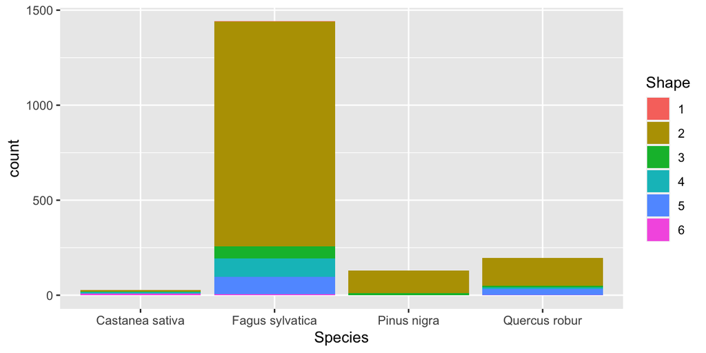

```r
# stacked bar chart
FI_Murcia_sub$Shape<- as.factor(FI_Murcia_sub$Shape)
ggplot(FI_Murcia_sub,
aes(x = Species,
fill = Shape)) + geom_bar(position = "stack")
```

From the chart, we can see for example, that the most common species is F. sylvatica. An the most common shape for all the species is 2

**Stacked is the default, so the last line could have also been written as `geom_bar()`.**

## Grouped bar chart

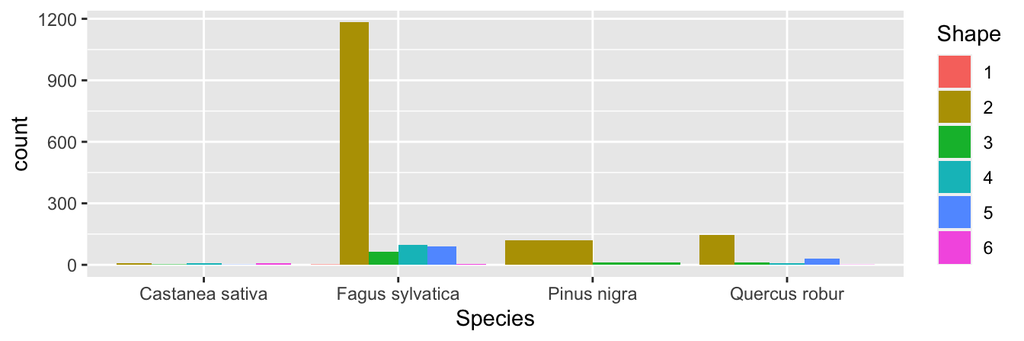

```r
ggplot(FI_Murcia_sub,
      aes(x = Species,
          fill = Shape)) + geom_bar(position = "dodge")
```

By default, zero count bars are dropped and the remaining bars are made wider. This may not be the behavior you want. You can modify this using the `position = position_dodge(preserve = "single")` option.

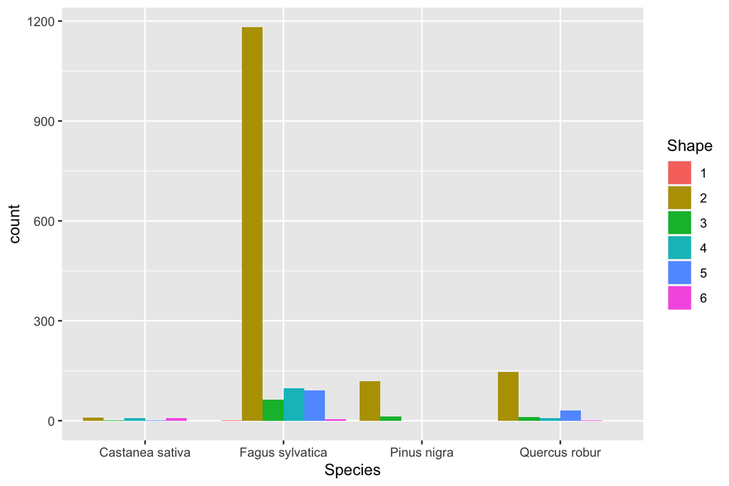

```r
ggplot(FI_Murcia_sub,
      aes(x = Species,
          fill = Shape)) +
        geom_bar(position = position_dodge(preserve="single"))
```

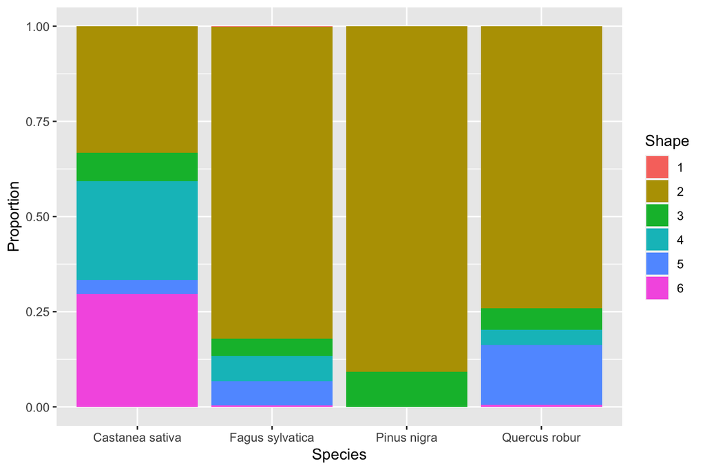

```r
#Segmented bar chart
FI_Murcia_sub$Shape<- as.factor(FI_Murcia_sub$Shape)
ggplot(FI_Murcia_sub,
      aes(x = Species,
          fill = Shape)) +
        geom_bar(position = "fill") + labs(y="Proportion")
```

This type of plot is particularly useful if the goal is to compare the percentage of a category in one variable across each level of another variable.

## Quantitative vs Quantitative

The simplest display of two quantitative variables is a scatterplot, with each variable represented on an axis.

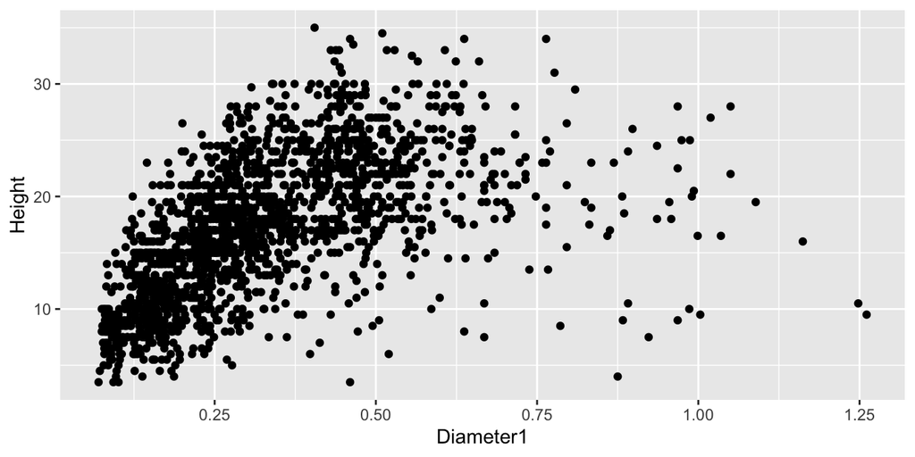

```r
# simple scatterplot
ggplot(FI_Murcia_sub,
aes(x = Diameter1, y = Height)) +
  geom_point()
```

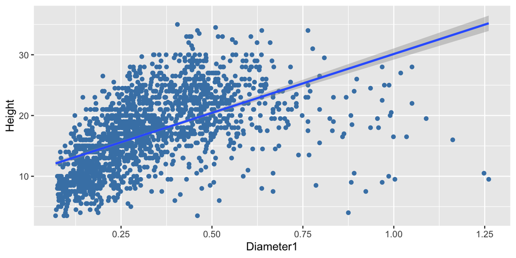

```r
# scatterplot with linear fit line
ggplot(FI_Murcia_sub,
aes(x = Diameter1, y = Height)) +
  geom_point(color="steelblue") +
  geom_smooth(method = "lm")
```

Clearly, Height increases with Diameter. However a straight line does not capture this non-linear effect. A polynomial regression line will fit better here.

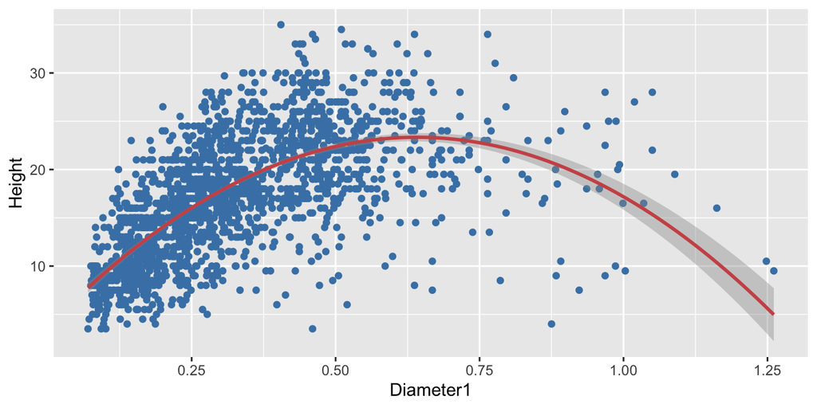

```r
# scatterplot with quadratic line of best fit
ggplot(FI_Murcia_sub,
aes(x = Diameter1, y = Height)) +
  geom_point(color="steelblue") +
  geom_smooth(method = "lm", formula = y ~ poly(x, 2),
  color = "indianred3")
```

Finally, a smoothed nonparametric fit line can often provide a good picture of the relationship. The default in **`ggplot2`** is a loess line which stands for for locally weighted scatterplot smoothing.

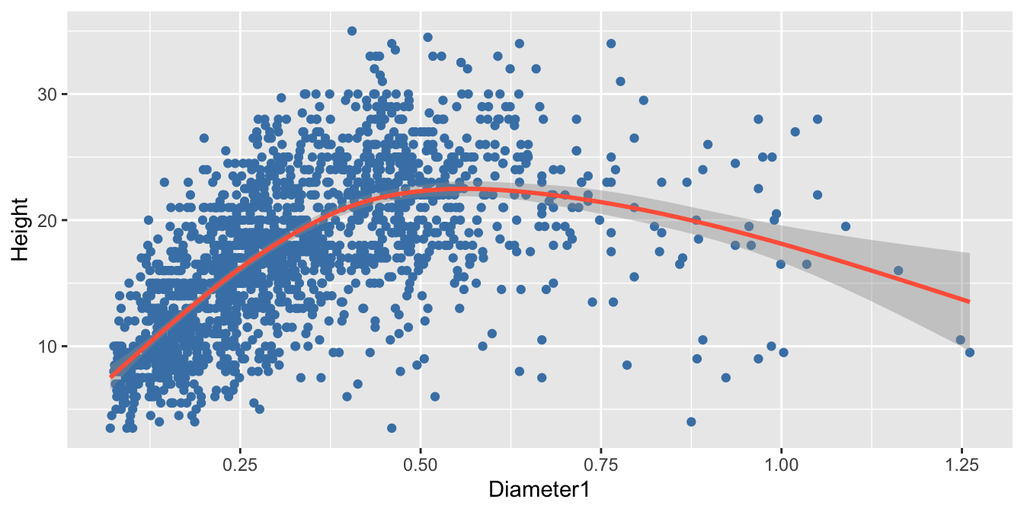

```r
# scatterplot with quadratic line of best fit
ggplot(FI_Murcia_sub,
aes(x = Diameter1, y = Height)) +
  geom_point(color = "steelblue") +
  geom_smooth(color = "tomato")
```

## Line plot

When one of the two variables represents time, a line plot can be an effective method of displaying relationship.

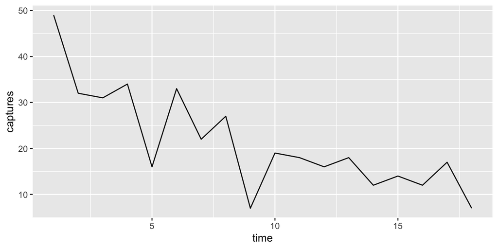

```r
library(curl)
rats <- read.csv(curl("https://raw.githubusercontent.com/orrortega/statistics-natural-resources/main/data/LeslieandDaviesRats.csv"))
ggplot(rats,
       aes(x = time, y = captures)) +
  geom_line()
```

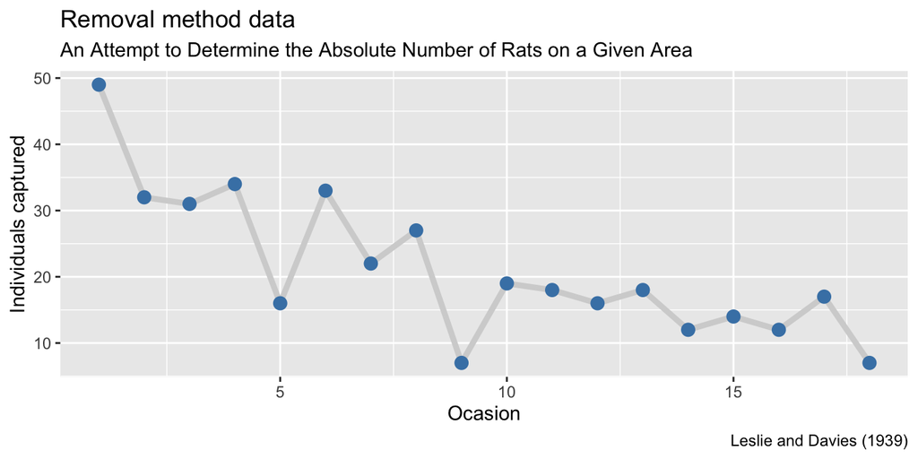

```r
# line plot with points and improved labeling
ggplot(rats,
  aes(x = time, y = captures)) +
geom_line(size = 1.5, color = "lightgrey") + geom_point(size = 3, color = "steelblue") +
labs(y = "Individuals captured", x = "Ocasion",
title = "Removal method data", subtitle = "An Attempt to Determine the Absolute Number of Rats on a Given Area",
caption = "Leslie and Davies (1939)")
```

**Time dependent data is covered in more detail under Time series.**

## Categorical vs Quantitative

When plotting the relationship between a categorical variable and a quantitative variable, a large number of graph types are available.

These include bar charts using summary statistics, grouped kernel density plots, side-by-side box plots, side-by-side violin plots, and Cleveland plots.

## Bar chart (on summary statistics)

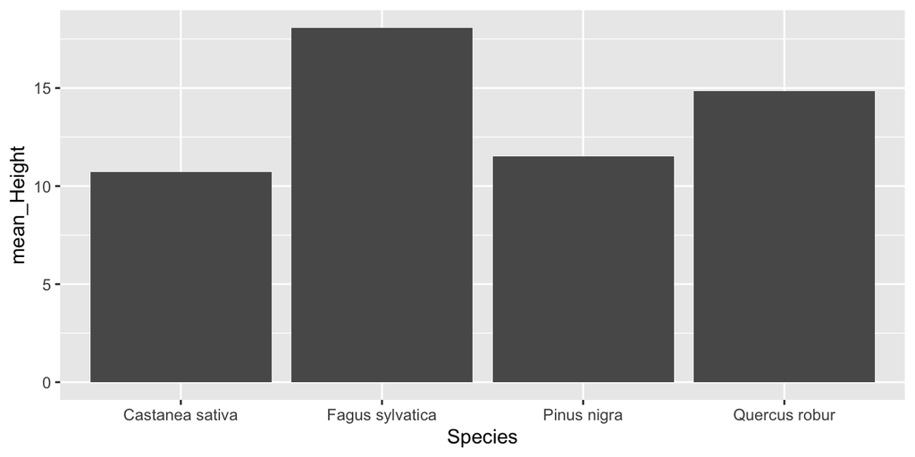

```r
# calculate mean salary for each rank
plotdata <- FI_Murcia_sub %>%
    group_by(Species) %>%
    summarize(mean_Height = mean(Height))
# plot mean salaries
ggplot(plotdata,
       aes(x = Species, y = mean_Height)) +
  geom_bar(stat = "identity")
```

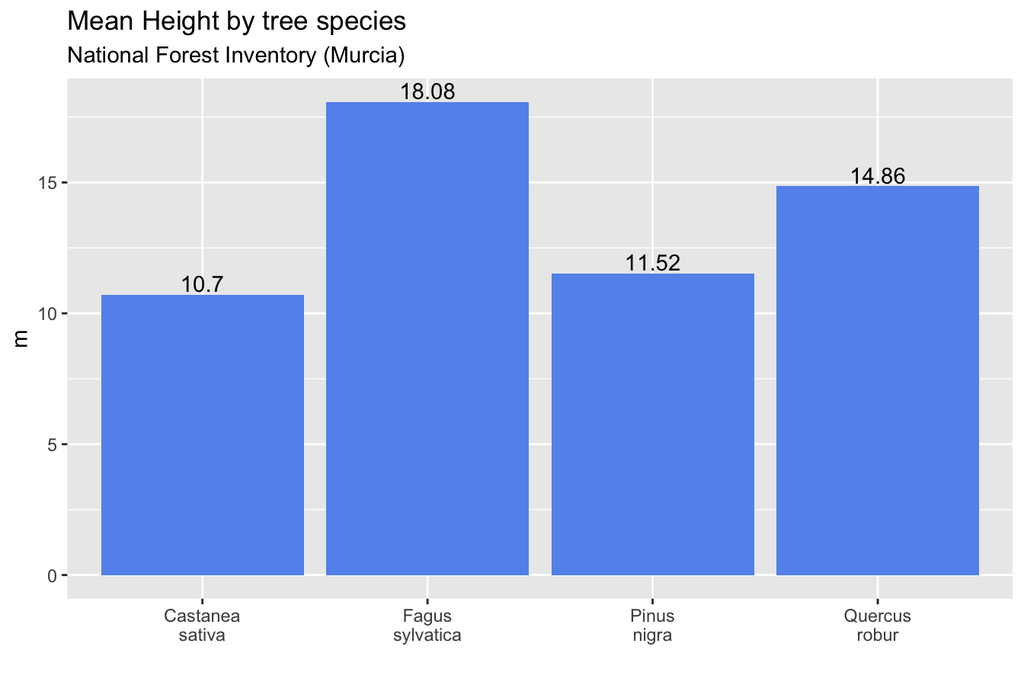

```r
# plot mean heights in a more attractive fashion
library(scales)
ggplot(plotdata,
      aes(x = factor(Species,
          labels = c("Castanea\nsativa", "Fagus\nsylvatica", "Pinus\nnigra", "Quercus\nrobur")), y = mean_Height)) +
    geom_bar(stat = "identity", fill = "cornflowerblue") +
    geom_text(aes(label = round(mean_Height, 2)),
      vjust = -0.2) +
  labs(title = "Mean Height by tree species",
    subtitle = "National Forest Inventory (Murcia)", x = "",
    y = "m")
```

## Grouped kernel density plots

One can compare groups on a numeric variable by superimposing kernel density plots in a single graph.

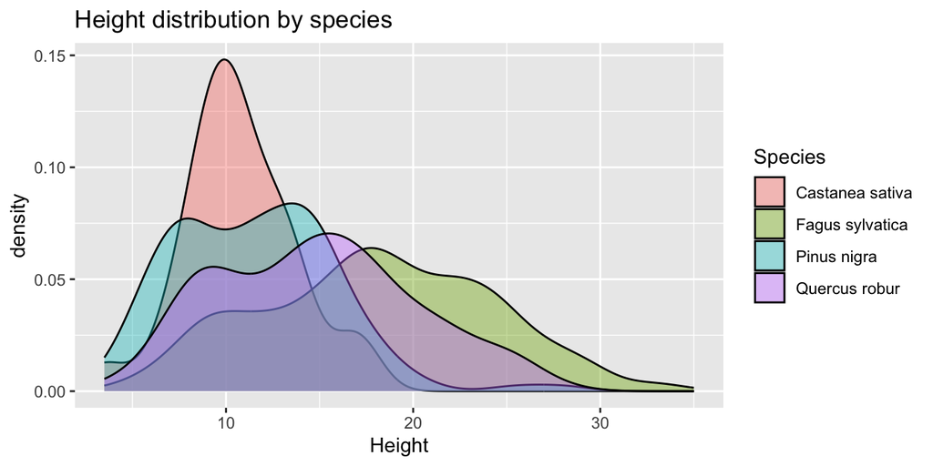

```r
# by rank using kernel density plots
ggplot(FI_Murcia_sub,
    aes(x = Height, fill = Species)) +
  geom_density(alpha = 0.4) +
  labs(title = "Height distribution by species")
```

`alpha` values range from 0 (transparent) to 1 (opaque)

## Box plots

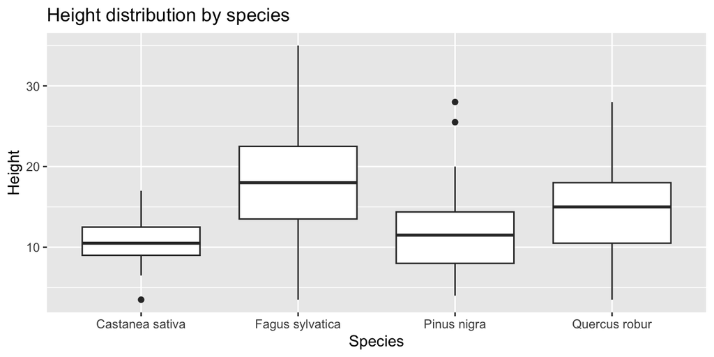

```r
# plot the distribution of salaries by rank using boxplots
ggplot(FI_Murcia_sub,
      aes(x = Species, y = Height)) +
  geom_boxplot() +
labs(title = "Height distribution by species")
```

## Violin plots

Violin plots are similar to kernel density plots, but are mirrored and rotated 90$^\circ$ .

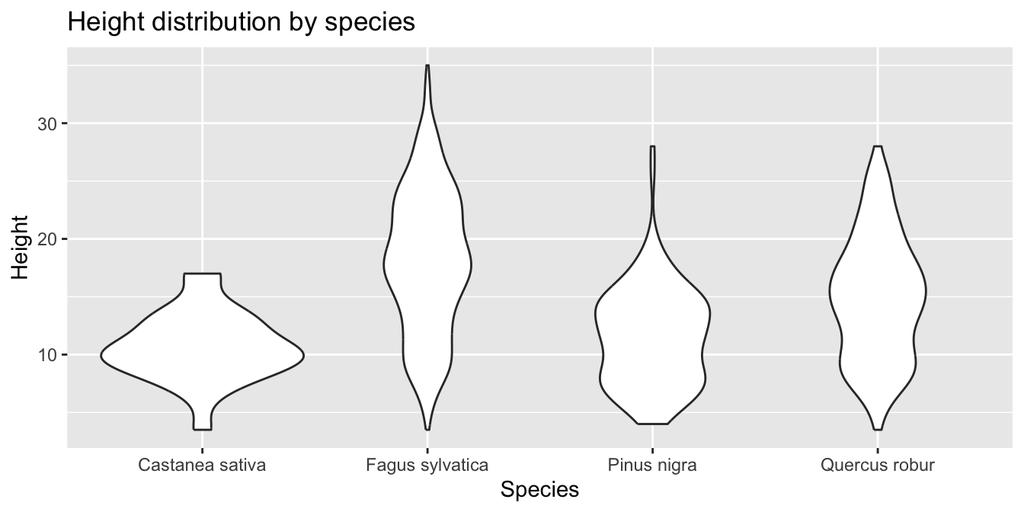

```r
 # plot the distribution of salaries by rank using violin plots
ggplot(FI_Murcia_sub,
      aes(x = Species, y = Height)) +
      geom_violin() +
      labs(title = "Height distribution by species")
```

A useful variation is to superimpose boxplots on violin plots.

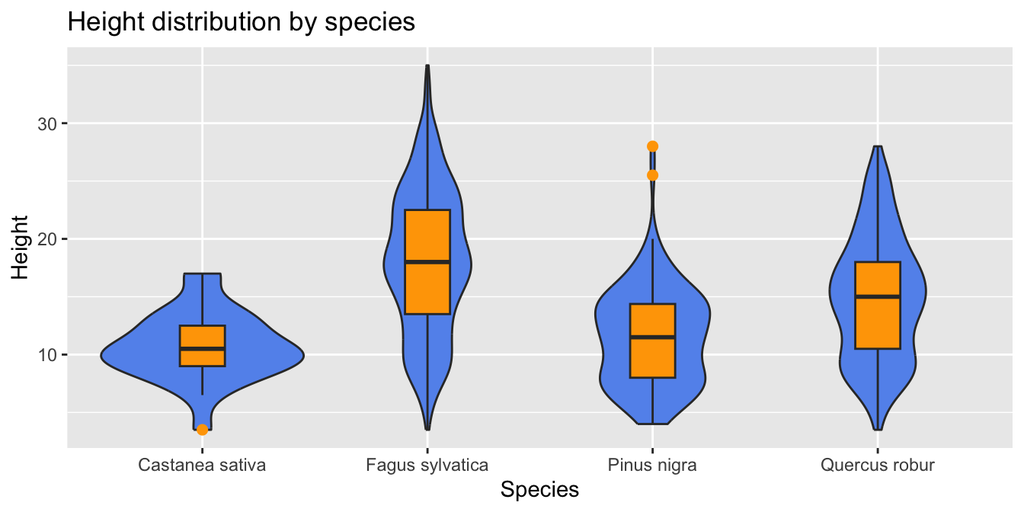

```r
# plot the distribution of salaries by rank using violin plots
ggplot(FI_Murcia_sub,
      aes(x = Species, y = Height)) +
      geom_violin(fill = "cornflowerblue") +
      geom_boxplot(width = .2, fill = "orange", outlier.color = "orange", outlier.size = 2) +
      labs(title = "Height distribution by species")
```

## Cleveland Dot Charts

Cleveland plots are useful when you want to compare a numeric statistic for a large number of groups.

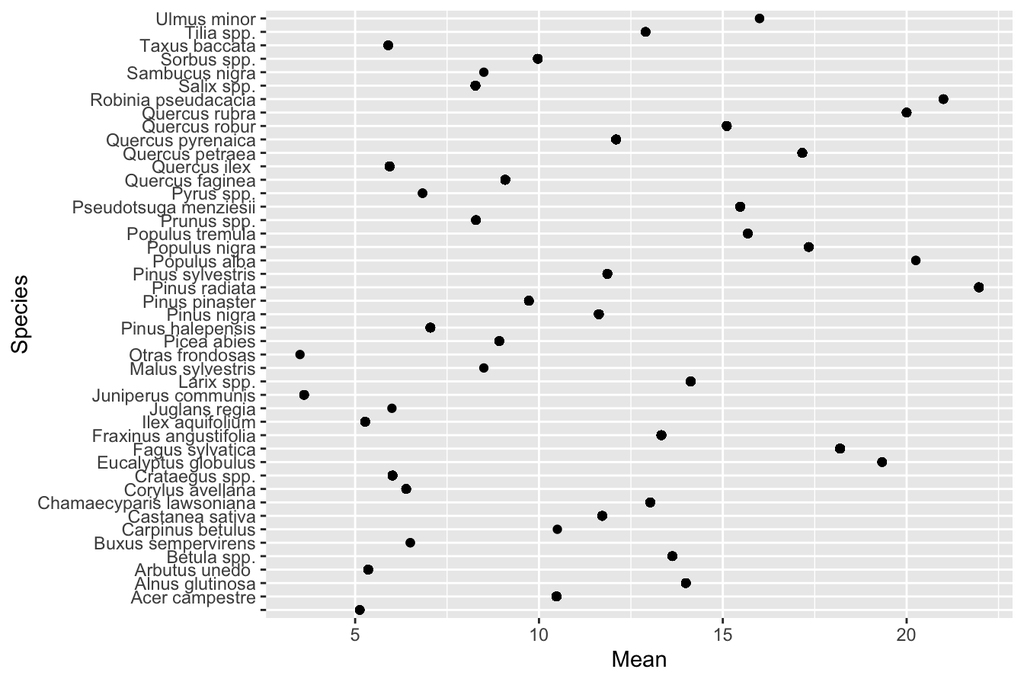

```r
# plot the distribution of salaries by rank using violin plots
plotdata<-FI_Murcia %>%
    group_by(Species) %>%
    mutate(Mean = mean(Height, na.rm=TRUE))
ggplot(plotdata,
      aes(x = Mean, y = Species)) +
      geom_point()
```

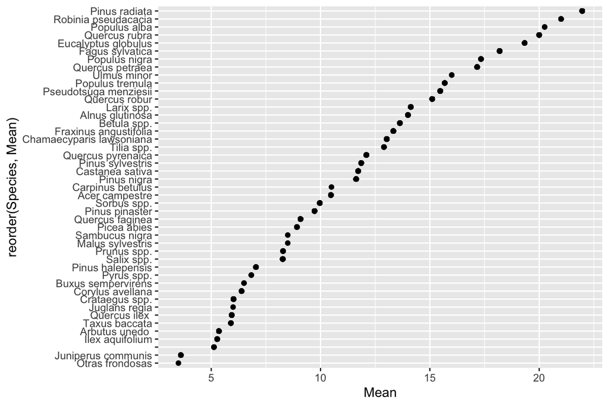

```r
# plot the distribution of salaries by rank using violin plots
ggplot(plotdata,
      aes(x = Mean, y = reorder(Species,Mean))) +
      geom_point()
```